| title: “homework_1210” |
| --- |
| author: “홍영화” |
| date: “2018년 12월 15일” |
| output: html_document |

#1.필요한 패키지

`r library(ggplot2)`

`## Warning: package 'ggplot2' was built under R version 3.4.4`

`r library(dplyr)`

`## Warning: package 'dplyr' was built under R version 3.4.4`

`r library(rpart) library(rpart.plot)`

`## Warning: package 'rpart.plot' was built under R version 3.4.4`

#2.파일 불러오기

`r baseball_raw <- read.csv('../BaseballHitters.csv') baseball <- subset(baseball_raw, select= -c(league87,team87)) baseball <- baseball[-c(177,294,44,220,215,25,81,111,107,284,216,36,18,56,91,320,113,194,321,151,7,19,242,123,221,230,45,277,54,228,156,298,92,121,181,243,191,68,118,55,264,153,125,102,75,32,303,317,106,252,149,70,316,293,40,310,90,100,258,15),]`

#3.데이터 살펴보기

`r #결측치 확인하기 --> salary87에만 결측치가 존재한다. colSums(is.na(baseball))`

`## X firstName lastName AB86 H86 HR86 ## 0 0 0 0 0 0 ## R86 RBI86 W86 years careerAB careerH ## 0 0 0 0 0 0 ## careerHR careerR careerRBI careerW league86 division86 ## 0 0 0 0 0 0 ## team86 position86 PO86 A86 E86 salary87 ## 0 0 0 0 0 46`

`r #결측치 제외하기 baseball <- baseball %>% filter(is.na(salary87) == FALSE)`

`## Warning: package 'bindrcpp' was built under R version 3.4.4`

`r colSums(is.na(baseball))`

`## X firstName lastName AB86 H86 HR86 ## 0 0 0 0 0 0 ## R86 RBI86 W86 years careerAB careerH ## 0 0 0 0 0 0 ## careerHR careerR careerRBI careerW league86 division86 ## 0 0 0 0 0 0 ## team86 position86 PO86 A86 E86 salary87 ## 0 0 0 0 0 0`

`r summary(baseball)`

`## X firstName lastName AB86 ## Min. : 2.00 Mike : 10 Davis : 6 Min. :127.0 ## 1st Qu.: 88.75 Steve : 6 Reynolds: 3 1st Qu.:286.8 ## Median :172.00 Dave : 5 Wilson : 3 Median :415.5 ## Mean :167.97 Jim : 5 Bell : 2 Mean :408.7 ## 3rd Qu.:248.25 Rick : 5 Bradley : 2 3rd Qu.:526.5 ## Max. :322.00 Tony : 5 Clark : 2 Max. :687.0 ## (Other):180 (Other) :198 ## H86 HR86 R86 RBI86 ## Min. : 32.00 Min. : 0.00 Min. : 13.00 Min. : 9.00 ## 1st Qu.: 72.75 1st Qu.: 5.00 1st Qu.: 34.00 1st Qu.: 31.00 ## Median :106.00 Median : 9.00 Median : 53.00 Median : 48.00 ## Mean :109.90 Mean :11.86 Mean : 55.50 Mean : 52.46 ## 3rd Qu.:145.25 3rd Qu.:18.00 3rd Qu.: 73.25 3rd Qu.: 72.25 ## Max. :238.00 Max. :40.00 Max. :130.00 Max. :121.00 ## ## W86 years careerAB careerH ## Min. : 3.00 Min. : 1.000 Min. : 196.0 Min. : 44.0 ## 1st Qu.: 23.75 1st Qu.: 4.000 1st Qu.: 926.8 1st Qu.: 229.2 ## Median : 37.00 Median : 6.000 Median : 2089.5 Median : 560.5 ## Mean : 41.56 Mean : 7.472 Mean : 2733.1 Mean : 741.3 ## 3rd Qu.: 57.00 3rd Qu.:10.250 3rd Qu.: 3926.5 3rd Qu.:1065.8 ## Max. :105.00 Max. :24.000 Max. :14053.0 Max. :4256.0 ## ## careerHR careerR careerRBI careerW ## Min. : 0.00 Min. : 18.0 Min. : 10.0 Min. : 8.00 ## 1st Qu.: 16.00 1st Qu.: 115.2 1st Qu.: 105.5 1st Qu.: 78.75 ## Median : 41.00 Median : 276.0 Median : 251.5 Median : 178.50 ## Mean : 72.32 Mean : 371.6 Mean : 342.0 Mean : 272.11 ## 3rd Qu.: 92.25 3rd Qu.: 507.0 3rd Qu.: 437.5 3rd Qu.: 342.75 ## Max. :548.00 Max. :2165.0 Max. :1659.0 Max. :1566.00 ## ## league86 division86 team86 position86 PO86 ## A:113 E:108 Chi. : 16 C :25 Min. : 0.0 ## N:103 W:108 N.Y. : 16 3B :24 1st Qu.: 114.8 ## S.F. : 12 2B :22 Median : 216.5 ## Cle. : 11 SS :21 Mean : 285.4 ## Bal. : 10 1B :20 3rd Qu.: 325.0 ## Det. : 10 RF :19 Max. :1377.0 ## (Other):141 (Other):85 ## A86 E86 salary87 ## Min. : 0.0 Min. : 0.000 Min. : 67.5 ## 1st Qu.: 8.0 1st Qu.: 3.000 1st Qu.: 200.0 ## Median : 47.5 Median : 7.000 Median : 440.0 ## Mean :120.2 Mean : 8.662 Mean : 540.6 ## 3rd Qu.:205.2 3rd Qu.:13.000 3rd Qu.: 750.0 ## Max. :487.0 Max. :29.000 Max. :2460.0 ##`

#4-1.선형회귀분석

`r #선형회귀 모형A fitA <- lm(salary87~.,data=baseball %>% select(-c('X','firstName','lastName'))) summary(fitA)`

`## ## Call: ## lm(formula = salary87 ~ ., data = baseball %>% select(-c("X", ## "firstName", "lastName"))) ## ## Residuals: ## Min 1Q Median 3Q Max ## -755.3 -139.7 0.0 119.2 718.4 ## ## Coefficients: ## Estimate Std. Error t value Pr(>|t|) ## (Intercept) 252.32670 411.77937 0.613 0.540943 ## AB86 -2.24003 0.73944 -3.029 0.002881 ** ## H86 8.96594 2.62271 3.419 0.000808 *** ## HR86 2.12103 7.62608 0.278 0.781291 ## R86 -4.20106 3.63827 -1.155 0.250030 ## RBI86 0.98013 3.06869 0.319 0.749865 ## W86 6.84141 2.01486 3.395 0.000874 *** ## years 4.43437 13.13198 0.338 0.736072 ## careerAB -0.21726 0.15101 -1.439 0.152281 ## careerH 0.08384 0.75900 0.110 0.912191 ## careerHR 0.22710 1.79501 0.127 0.899488 ## careerR 1.92198 0.83604 2.299 0.022873 * ## careerRBI 0.60271 0.74941 0.804 0.422509 ## careerW -0.80257 0.34332 -2.338 0.020710 * ## league86N -42.74334 147.48676 -0.290 0.772356 ## division86W -353.54445 213.79589 -1.654 0.100262 ## team86Bal. -377.93679 361.36352 -1.046 0.297285 ## team86Bos. -342.48476 380.22249 -0.901 0.369147 ## team86Cal. -344.16118 222.17942 -1.549 0.123456 ## team86Chi. -222.99355 216.91232 -1.028 0.305566 ## team86Cin. -269.80347 151.11572 -1.785 0.076189 . ## team86Cle. -487.97893 370.28460 -1.318 0.189537 ## team86Det. -633.11349 360.47548 -1.756 0.081046 . ## team86Hou. -165.71968 147.48913 -1.124 0.262952 ## team86K.C. -226.49383 212.82916 -1.064 0.288924 ## team86L.A. 13.71079 154.28366 0.089 0.929304 ## team86Mil. -527.08519 372.87281 -1.414 0.159530 ## team86Min. -159.56888 206.58852 -0.772 0.441077 ## team86Mon. -522.59112 266.63945 -1.960 0.051834 . ## team86N.Y. -392.23920 302.56285 -1.296 0.196806 ## team86Oak. -115.30085 225.18359 -0.512 0.609373 ## team86Phi. -432.84611 270.51164 -1.600 0.111652 ## team86Pit. -618.58129 268.01721 -2.308 0.022348 * ## team86S.D. -195.23458 140.94365 -1.385 0.168022 ## team86S.F. -161.32304 141.81473 -1.138 0.257093 ## team86Sea. -260.40334 204.99687 -1.270 0.205926 ## team86St.L. -362.06426 271.50085 -1.334 0.184341 ## team86Tex. -289.61282 211.27491 -1.371 0.172462 ## team86Tor. -343.99826 373.05514 -0.922 0.357932 ## position861O 74.75694 303.58910 0.246 0.805826 ## position8623 308.70043 357.83020 0.863 0.389661 ## position862B 395.40622 221.49287 1.785 0.076225 . ## position862S 703.20135 351.82252 1.999 0.047420 * ## position8632 332.78871 357.34848 0.931 0.353190 ## position863B 449.37846 217.00221 2.071 0.040064 * ## position863O -229.19696 362.61751 -0.632 0.528296 ## position863S 355.93385 258.12630 1.379 0.169947 ## position86C 320.69334 120.84284 2.654 0.008805 ** ## position86CD 167.56570 345.28872 0.485 0.628168 ## position86CF 280.07024 185.92670 1.506 0.134053 ## position86DH 93.20000 221.85188 0.420 0.675006 ## position86DO 134.39727 267.95867 0.502 0.616703 ## position86LF 278.86654 182.02969 1.532 0.127605 ## position86O1 232.44688 221.32209 1.050 0.295263 ## position86OD 334.16654 328.69813 1.017 0.310942 ## position86OF 315.04633 172.96516 1.821 0.070506 . ## position86OS 127.14071 267.91564 0.475 0.635785 ## position86RF 287.50220 191.69111 1.500 0.135735 ## position86S3 1153.53624 404.05109 2.855 0.004906 ** ## position86SS 469.84996 227.51814 2.065 0.040611 * ## position86UT 249.86965 204.43578 1.222 0.223509 ## PO86 0.54075 0.21435 2.523 0.012675 * ## A86 -0.07133 0.50473 -0.141 0.887798 ## E86 -7.68273 5.41261 -1.419 0.157826 ## --- ## Signif. codes: 0 '***' 0.001 '**' 0.01 '*' 0.05 '.' 0.1 ' ' 1 ## ## Residual standard error: 269.9 on 152 degrees of freedom ## Multiple R-squared: 0.7412, Adjusted R-squared: 0.634 ## F-statistic: 6.91 on 63 and 152 DF, p-value: < 2.2e-16`

`r mean((baseball$salary87 - predict(fitA))^2) #MSE=51262.76`

`## [1] 51262.76`

```r #다음 변수값이 통계적으로 유의하다고 판단됨 #Coefficients: # Estimate Std. Error t value Pr(>|t|)  
#(Intercept) 252.32670 411.77937 0.613 0.540943 #AB86 -2.24003 0.73944 -3.029 0.002881 ** #H86 8.96594 2.62271 3.419 0.000808 *#careerR 1.92198 0.83604 2.299 0.022873*  
#careerW -0.80257 0.34332 -2.338 0.020710 * #team86Pit. -618.58129 268.01721 -2.308 0.022348 *  
#position862S 703.20135 351.82252 1.999 0.047420 *  
#position863B 449.37846 217.00221 2.071 0.040064 * #position86C 320.69334 120.84284 2.654 0.008805 #position86S3 1153.53624 404.05109 2.855 0.004906 ** #position86SS 469.84996 227.51814 2.065 0.040611 *  
#PO86 0.54075 0.21435 2.523 0.012675 *

#선형회귀 모형b ##유의하다고 판단된 변수 중 하나만 추출하여 회귀분석 fitB <- lm(salary87~H86,data=baseball) #summary(fitB) mean((baseball$salary87 - predict(fitB))^2) #MSE=144303.3 ```

`## [1] 144303.3`

`r ggplot(data=baseball, aes(x=H86, y=salary87)) + geom_point() + geom_smooth(method='lm')`

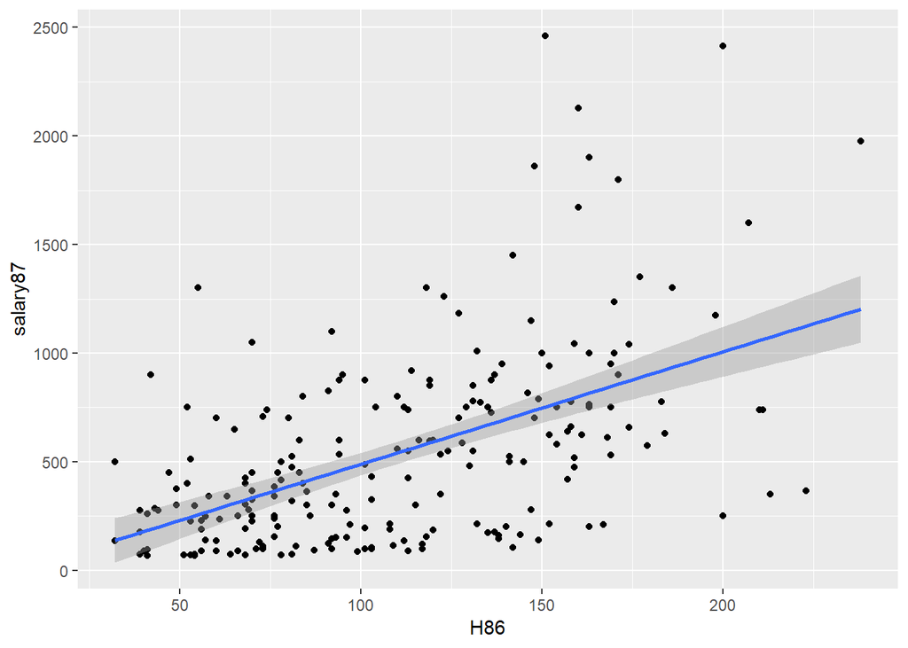

`r #선형회귀 모형C ##유의하다고 판단된 변수들 모두 추출하여 회귀분석 fitC <- lm(salary87~AB86+H86+W86+careerR+careerW+team86+position86+PO86,data=baseball) #summary(fitC) mean((baseball$salary87 - predict(fitC))^2) #MSE=59597.94`

`## [1] 59597.94`

`r #선형회귀 모형D ##그 변수들끼리 interaction 적용하여 회귀분석 fitD <- lm(salary87~AB86+H86+W86+careerR+careerW+PO86+team86*position86,data=baseball) #summary(fitD) mean((baseball$salary87 - predict(fitD))^2) #MSE=4528.309`

`## [1] 4528.309`

`r #선형회귀 모형E ##여러 변수에 interection 적용하여 회귀분석 fitE <- lm(salary87~AB86+H86*W86+careerR*careerW+PO86+team86*position86,data=baseball) #summary(fitE) mean((baseball$salary87 - predict(fitE))^2) #MSE=3680.111`

`## [1] 3680.111`

`r #선형회귀 모형F ##모든 변수에 interaction 적용하여 회귀분석...(?) fitF <- lm(salary87~AB86*H86*W86*careerR*careerW*PO86*team86*position86,data=baseball) #summary(fitF) mean((baseball$salary87 - predict(fitF))^2) #MSE=3.094031e-21`

`## [1] 3.094031e-21`

`r #ggPredict(fitF,interactive=TRUE)`

`r #결정나무 모형A fitG <- rpart(salary87~., baseball %>% select(-c("X", "firstName", "lastName")), control = rpart.control(maxdepth=4)) summary(fitG)`

`## Call: ## rpart(formula = salary87 ~ ., data = baseball %>% select(-c("X", ## "firstName", "lastName")), control = rpart.control(maxdepth = 4)) ## n= 216 ## ## CP nsplit rel error xerror xstd ## 1 0.41658918 0 1.0000000 1.0081950 0.1587786 ## 2 0.14262890 1 0.5834108 0.6352753 0.1181224 ## 3 0.11026606 2 0.4407819 0.7359026 0.1337347 ## 4 0.04131753 3 0.3305159 0.6724278 0.1286517 ## 5 0.02400220 4 0.2891983 0.6690358 0.1192571 ## 6 0.01779325 5 0.2651961 0.6540258 0.1149228 ## 7 0.01575767 6 0.2474029 0.6765563 0.1195595 ## 8 0.01000000 7 0.2316452 0.6593131 0.1193249 ## ## Variable importance ## careerH careerAB careerR careerW careerRBI years RBI86 ## 14 13 13 12 12 9 5 ## team86 HR86 R86 W86 careerHR AB86 H86 ## 5 4 3 2 2 2 1 ## PO86 ## 1 ## ## Node number 1: 216 observations, complexity param=0.4165892 ## mean=540.6324, MSE=198088.5 ## left son=2 (90 obs) right son=3 (126 obs) ## Primary splits: ## careerH < 450 to the left, improve=0.4165892, (0 missing) ## careerR < 218.5 to the left, improve=0.4075307, (0 missing) ## careerAB < 1929.5 to the left, improve=0.4052339, (0 missing) ## careerRBI < 180.5 to the left, improve=0.3801651, (0 missing) ## careerW < 115.5 to the left, improve=0.3527149, (0 missing) ## Surrogate splits: ## careerAB < 1551 to the left, agree=0.981, adj=0.956, (0 split) ## careerR < 210.5 to the left, agree=0.968, adj=0.922, (0 split) ## careerRBI < 180.5 to the left, agree=0.940, adj=0.856, (0 split) ## careerW < 131 to the left, agree=0.907, adj=0.778, (0 split) ## years < 4.5 to the left, agree=0.870, adj=0.689, (0 split) ## ## Node number 2: 90 observations, complexity param=0.01575767 ## mean=200.7352, MSE=15330.61 ## left son=4 (50 obs) right son=5 (40 obs) ## Primary splits: ## careerR < 103.5 to the left, improve=0.4886555, (0 missing) ## careerRBI < 114.5 to the left, improve=0.4848888, (0 missing) ## careerAB < 818.5 to the left, improve=0.4837833, (0 missing) ## careerH < 207.5 to the left, improve=0.4837833, (0 missing) ## careerW < 105.5 to the left, improve=0.4771157, (0 missing) ## Surrogate splits: ## careerAB < 818.5 to the left, agree=0.933, adj=0.850, (0 split) ## careerH < 189.5 to the left, agree=0.933, adj=0.850, (0 split) ## careerRBI < 98 to the left, agree=0.867, adj=0.700, (0 split) ## careerW < 78.5 to the left, agree=0.822, adj=0.600, (0 split) ## years < 3.5 to the left, agree=0.789, adj=0.525, (0 split) ## ## Node number 3: 126 observations, complexity param=0.1426289 ## mean=783.4162, MSE=187164.4 ## left son=6 (99 obs) right son=7 (27 obs) ## Primary splits: ## RBI86 < 80.5 to the left, improve=0.2587777, (0 missing) ## AB86 < 421.5 to the left, improve=0.2105031, (0 missing) ## PO86 < 882.5 to the left, improve=0.2078627, (0 missing) ## R86 < 96 to the left, improve=0.1951386, (0 missing) ## W86 < 60.5 to the left, improve=0.1928699, (0 missing) ## Surrogate splits: ## HR86 < 20.5 to the left, agree=0.905, adj=0.556, (0 split) ## R86 < 88.5 to the left, agree=0.833, adj=0.222, (0 split) ## AB86 < 609 to the left, agree=0.817, adj=0.148, (0 split) ## careerHR < 244.5 to the left, agree=0.817, adj=0.148, (0 split) ## PO86 < 965 to the left, agree=0.817, adj=0.148, (0 split) ## ## Node number 4: 50 observations ## mean=123.32, MSE=2371.038 ## ## Node number 5: 40 observations ## mean=297.5042, MSE=14674.46 ## ## Node number 6: 99 observations, complexity param=0.04131753 ## mean=668.4846, MSE=78357.61 ## left son=12 (47 obs) right son=13 (52 obs) ## Primary splits: ## AB86 < 394.5 to the left, improve=0.2278930, (0 missing) ## team86 splits as RLRLRRRLLRRRRLRRLRLRLRLL, improve=0.2033505, (0 missing) ## H86 < 88 to the left, improve=0.1980635, (0 missing) ## position86 splits as -R--R-LRLLRLR-RLR--R-RRRL, improve=0.1833304, (0 missing) ## R86 < 33.5 to the left, improve=0.1693005, (0 missing) ## Surrogate splits: ## H86 < 111 to the left, agree=0.919, adj=0.830, (0 split) ## R86 < 55 to the left, agree=0.869, adj=0.723, (0 split) ## RBI86 < 45.5 to the left, agree=0.848, adj=0.681, (0 split) ## W86 < 33.5 to the left, agree=0.768, adj=0.511, (0 split) ## HR86 < 9.5 to the left, agree=0.717, adj=0.404, (0 split) ## ## Node number 7: 27 observations, complexity param=0.1102661 ## mean=1204.832, MSE=360097.3 ## left son=14 (16 obs) right son=15 (11 obs) ## Primary splits: ## team86 splits as RRRLLL-L-L--L-R-RLL---LL, improve=0.4852563, (0 missing) ## careerR < 788 to the left, improve=0.3292718, (0 missing) ## careerHR < 256.5 to the left, improve=0.3008037, (0 missing) ## careerW < 556 to the left, improve=0.2885540, (0 missing) ## W86 < 52.5 to the left, improve=0.2720356, (0 missing) ## Surrogate splits: ## W86 < 69.5 to the left, agree=0.778, adj=0.455, (0 split) ## careerW < 556 to the left, agree=0.778, adj=0.455, (0 split) ## HR86 < 19.5 to the right, agree=0.741, adj=0.364, (0 split) ## R86 < 92 to the left, agree=0.741, adj=0.364, (0 split) ## careerHR < 256.5 to the left, agree=0.741, adj=0.364, (0 split) ## ## Node number 12: 47 observations, complexity param=0.01779325 ## mean=527.9256, MSE=55113.22 ## left son=24 (21 obs) right son=25 (26 obs) ## Primary splits: ## team86 splits as LL-LRR-LRLRL-RRR--LRLRLL, improve=0.2939102, (0 missing) ## position86 splits as -R--L-LRLLRLR-LLR--R---RL, improve=0.2575685, (0 missing) ## PO86 < 216.5 to the left, improve=0.1798370, (0 missing) ## league86 splits as LR, improve=0.1429595, (0 missing) ## years < 13.5 to the right, improve=0.1373352, (0 missing) ## Surrogate splits: ## league86 splits as LR, agree=0.851, adj=0.667, (0 split) ## position86 splits as -R--L-LRRRRLR-LLR--R---RL, agree=0.787, adj=0.524, (0 split) ## H86 < 77.5 to the left, agree=0.638, adj=0.190, (0 split) ## E86 < 2.5 to the left, agree=0.638, adj=0.190, (0 split) ## AB86 < 281.5 to the left, agree=0.617, adj=0.143, (0 split) ## ## Node number 13: 52 observations, complexity param=0.0240022 ## mean=795.5284, MSE=65369.69 ## left son=26 (30 obs) right son=27 (22 obs) ## Primary splits: ## team86 splits as LLRLRLLLLRLRRLRLLRRLLL-R, improve=0.3021233, (0 missing) ## position86 splits as -L--L--R--R-R-L-L--R-LRL-, improve=0.1656097, (0 missing) ## A86 < 401 to the right, improve=0.1234662, (0 missing) ## careerAB < 2319.5 to the left, improve=0.1031409, (0 missing) ## careerH < 652 to the left, improve=0.1013191, (0 missing) ## Surrogate splits: ## careerRBI < 336.5 to the left, agree=0.692, adj=0.273, (0 split) ## position86 splits as -L--L--L--R-R-L-L--R-LLL-, agree=0.673, adj=0.227, (0 split) ## E86 < 8.5 to the right, agree=0.673, adj=0.227, (0 split) ## careerH < 876 to the left, agree=0.654, adj=0.182, (0 split) ## careerHR < 78 to the left, agree=0.654, adj=0.182, (0 split) ## ## Node number 14: 16 observations ## mean=858.2292, MSE=104036.1 ## ## Node number 15: 11 observations ## mean=1708.981, MSE=303643.9 ## ## Node number 24: 21 observations ## mean=386.3096, MSE=22909.69 ## ## Node number 25: 26 observations ## mean=642.3077, MSE=51842.16 ## ## Node number 26: 30 observations ## mean=675.1825, MSE=20189.16 ## ## Node number 27: 22 observations ## mean=959.6363, MSE=80298.37`

`r plot(fitG, main='Decision Tree A') text(fitG)`

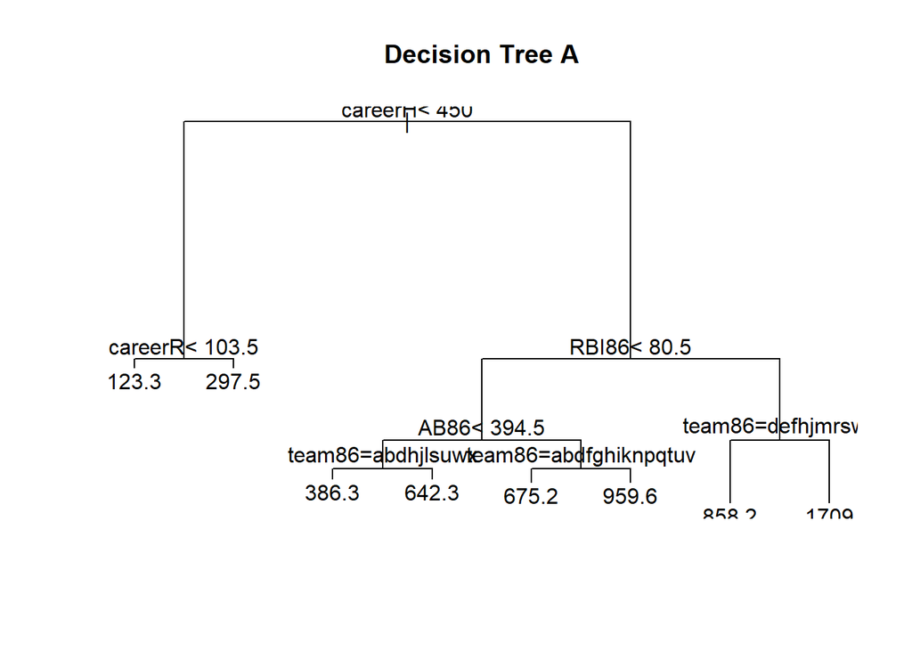

`r rpart.plot(fitG)`

`## Warning: Bad 'data' field in model 'call' (expected a data.frame or a matrix). ## To silence this warning: ## Call rpart.plot with roundint=FALSE, ## or rebuild the rpart model with model=TRUE.`

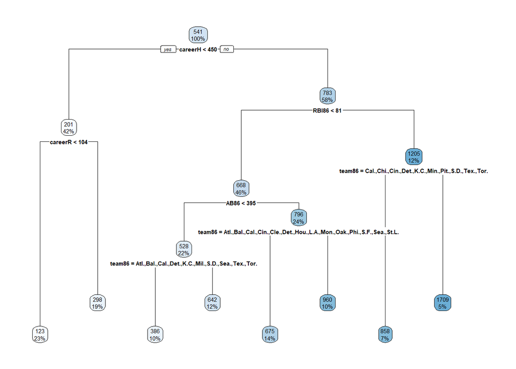

```r #Node number 4: 50 observations # mean=123.32, MSE=2371.038

#결정나무 모형B fitH <- rpart(salary87~., baseball %>% select(-c(“X”, “firstName”, “lastName”,“AB86”, “HR86” , “RBI86” , “years” , “careerH” , “careerHR” , “league86”, “A86”)), control = rpart.control(maxdepth=4)) summary(fitH) ```

`## Call: ## rpart(formula = salary87 ~ ., data = baseball %>% select(-c("X", ## "firstName", "lastName", "AB86", "HR86", "RBI86", "years", ## "careerH", "careerHR", "league86", "A86")), control = rpart.control(maxdepth = 4)) ## n= 216 ## ## CP nsplit rel error xerror xstd ## 1 0.40753069 0 1.0000000 1.0059973 0.1590413 ## 2 0.11292807 1 0.5924693 0.6173373 0.1160920 ## 3 0.08566959 2 0.4795412 0.7109803 0.1348607 ## 4 0.03851624 3 0.3938716 0.6506114 0.1187330 ## 5 0.02430312 4 0.3553554 0.6098290 0.1092558 ## 6 0.01000000 5 0.3310523 0.6239818 0.1170109 ## ## Variable importance ## careerR careerAB careerRBI careerW H86 position86 ## 20 18 18 17 9 6 ## R86 PO86 W86 team86 ## 6 6 1 1 ## ## Node number 1: 216 observations, complexity param=0.4075307 ## mean=540.6324, MSE=198088.5 ## left son=2 (94 obs) right son=3 (122 obs) ## Primary splits: ## careerR < 218.5 to the left, improve=0.4075307, (0 missing) ## careerAB < 1929.5 to the left, improve=0.4052339, (0 missing) ## careerRBI < 180.5 to the left, improve=0.3801651, (0 missing) ## careerW < 115.5 to the left, improve=0.3527149, (0 missing) ## H86 < 145.5 to the left, improve=0.2449774, (0 missing) ## Surrogate splits: ## careerAB < 1762.5 to the left, agree=0.954, adj=0.894, (0 split) ## careerRBI < 224 to the left, agree=0.935, adj=0.851, (0 split) ## careerW < 164 to the left, agree=0.907, adj=0.787, (0 split) ## H86 < 109.5 to the left, agree=0.681, adj=0.266, (0 split) ## position86 splits as -RLLRLLRRLLRR-RRRLLLLRRLR, agree=0.671, adj=0.245, (0 split) ## ## Node number 2: 94 observations, complexity param=0.02430312 ## mean=216.945, MSE=22218.57 ## left son=4 (74 obs) right son=5 (20 obs) ## Primary splits: ## careerW < 117.5 to the left, improve=0.4978874, (0 missing) ## careerAB < 1257.5 to the left, improve=0.4925267, (0 missing) ## careerRBI < 131 to the left, improve=0.4897314, (0 missing) ## careerR < 149.5 to the left, improve=0.4714815, (0 missing) ## team86 splits as RRRLLLRLLLRLLLLLLLRLLLLR, improve=0.2243385, (0 missing) ## Surrogate splits: ## careerRBI < 141.5 to the left, agree=0.926, adj=0.65, (0 split) ## careerAB < 1470 to the left, agree=0.872, adj=0.40, (0 split) ## careerR < 171 to the left, agree=0.862, adj=0.35, (0 split) ## team86 splits as RLLLLLLLLLRLLLLLLLLLLLLL, agree=0.809, adj=0.10, (0 split) ## PO86 < 584 to the left, agree=0.798, adj=0.05, (0 split) ## ## Node number 3: 122 observations, complexity param=0.1129281 ## mean=790.0309, MSE=190668.1 ## left son=6 (115 obs) right son=7 (7 obs) ## Primary splits: ## PO86 < 882.5 to the left, improve=0.2077194, (0 missing) ## R86 < 93.5 to the left, improve=0.2018879, (0 missing) ## W86 < 52.5 to the left, improve=0.1930456, (0 missing) ## H86 < 147.5 to the left, improve=0.1926032, (0 missing) ## team86 splits as RRRLLLLLLLLRLLRLRLLLLRLR, improve=0.1587964, (0 missing) ## Surrogate splits: ## position86 splits as -R--L--LLLLLL-LLL--L-LLLL, agree=0.951, adj=0.143, (0 split) ## ## Node number 4: 74 observations ## mean=162.2658, MSE=5993.583 ## ## Node number 5: 20 observations ## mean=419.2584, MSE=30257.99 ## ## Node number 6: 115 observations, complexity param=0.08566959 ## mean=740.9313, MSE=146724.4 ## left son=12 (105 obs) right son=13 (10 obs) ## Primary splits: ## R86 < 96 to the left, improve=0.2172398, (0 missing) ## H86 < 159.5 to the left, improve=0.1833574, (0 missing) ## team86 splits as RLRLLLLLLLLRLLRLRLLLLRLR, improve=0.1774907, (0 missing) ## W86 < 60.5 to the left, improve=0.1773497, (0 missing) ## position86 splits as -R--L--RLLRLR-LLR--L-RRRL, improve=0.1336652, (0 missing) ## Surrogate splits: ## H86 < 191 to the left, agree=0.948, adj=0.4, (0 split) ## team86 splits as LLRLLLLLLLLLLLLLLLLLLLLL, agree=0.922, adj=0.1, (0 split) ## ## Node number 7: 7 observations ## mean=1596.667, MSE=222332.6 ## ## Node number 12: 105 observations, complexity param=0.03851624 ## mean=685.8345, MSE=87997.92 ## left son=24 (33 obs) right son=25 (72 obs) ## Primary splits: ## H86 < 87.5 to the left, improve=0.1783591, (0 missing) ## position86 splits as -R--R--RLLRLR-RLR--R-RRRL, improve=0.1551701, (0 missing) ## R86 < 68 to the left, improve=0.1506731, (0 missing) ## team86 splits as RLRLRRRLLRRRRLRLLRLRLRLR, improve=0.1504936, (0 missing) ## W86 < 50.5 to the left, improve=0.1207250, (0 missing) ## Surrogate splits: ## R86 < 44 to the left, agree=0.924, adj=0.758, (0 split) ## W86 < 30.5 to the left, agree=0.810, adj=0.394, (0 split) ## position86 splits as -R--R--RLLRLR-RLR--L-RRRL, agree=0.790, adj=0.333, (0 split) ## careerAB < 8157.5 to the right, agree=0.714, adj=0.091, (0 split) ## team86 splits as RLRRRRRLRRRRRRRRRRRRRLRR, agree=0.714, adj=0.091, (0 split) ## ## Node number 13: 10 observations ## mean=1319.448, MSE=396797.5 ## ## Node number 24: 33 observations ## mean=500.7828, MSE=62547.63 ## ## Node number 25: 72 observations ## mean=770.6499, MSE=76773.76`

`r plot(fitH, main='Decision Tree B') text(fitH)`

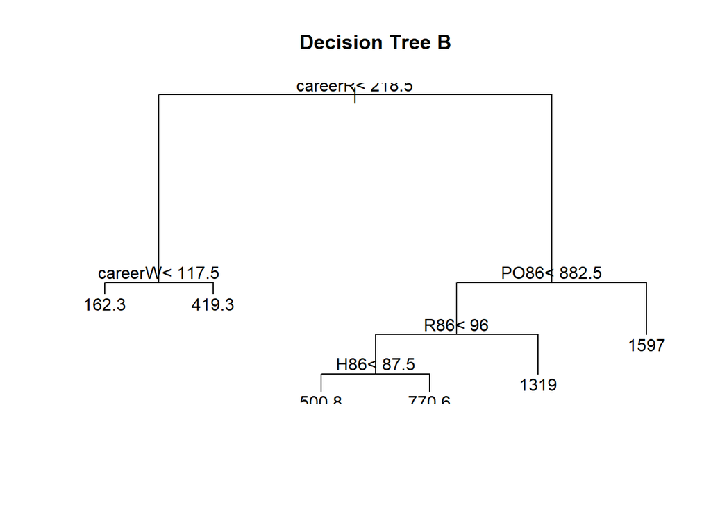

`r rpart.plot(fitH)`

`## Warning: Bad 'data' field in model 'call' (expected a data.frame or a matrix). ## To silence this warning: ## Call rpart.plot with roundint=FALSE, ## or rebuild the rpart model with model=TRUE.`

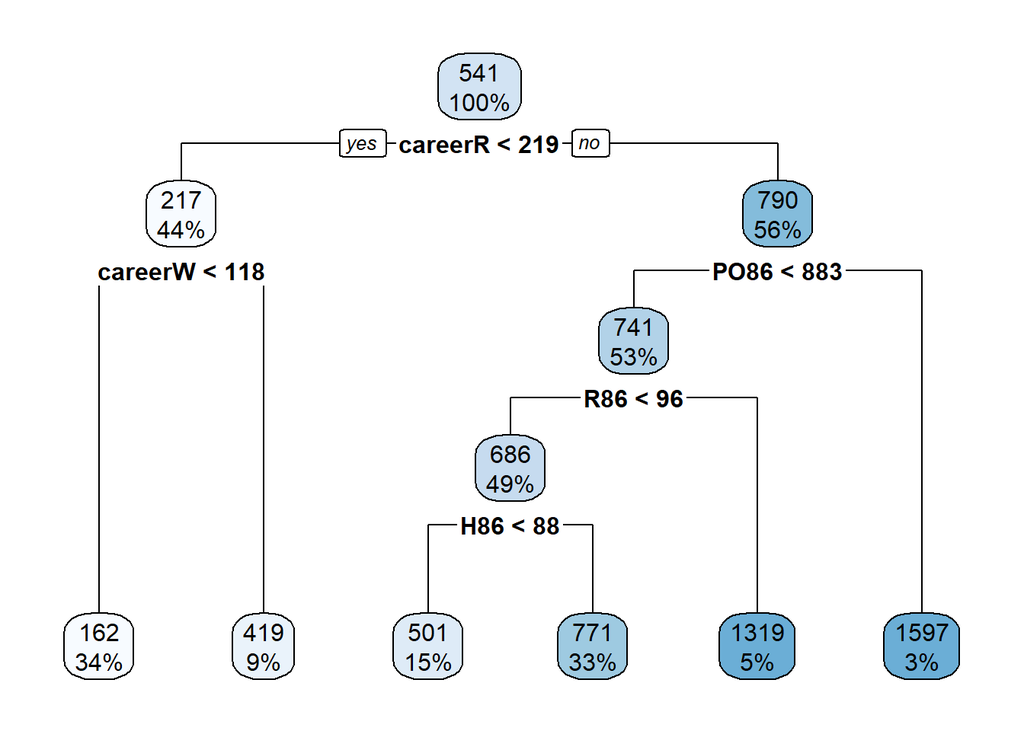

```r #Node number 4: 74 observations # mean=162.2658, MSE=5993.583

#결정나무 모형C fitI <- rpart(salary87~AB86+H86+W86+careerR+careerW+team86+position86+PO86, baseball %>% select(-c(“X”, “firstName”, “lastName”)), control = rpart.control(maxdepth=4)) summary(fitI) ```

`## Call: ## rpart(formula = salary87 ~ AB86 + H86 + W86 + careerR + careerW + ## team86 + position86 + PO86, data = baseball %>% select(-c("X", ## "firstName", "lastName")), control = rpart.control(maxdepth = 4)) ## n= 216 ## ## CP nsplit rel error xerror xstd ## 1 0.40753069 0 1.0000000 1.0049382 0.1582589 ## 2 0.11292807 1 0.5924693 0.6065482 0.1148683 ## 3 0.08472886 2 0.4795412 0.6613958 0.1283900 ## 4 0.02487612 4 0.3100835 0.6353073 0.1235428 ## 5 0.02430312 5 0.2852074 0.6093883 0.1132857 ## 6 0.01000000 6 0.2609043 0.6262096 0.1187850 ## ## Variable importance ## careerR careerW H86 AB86 position86 W86 ## 25 22 12 10 10 8 ## team86 PO86 ## 7 7 ## ## Node number 1: 216 observations, complexity param=0.4075307 ## mean=540.6324, MSE=198088.5 ## left son=2 (94 obs) right son=3 (122 obs) ## Primary splits: ## careerR < 218.5 to the left, improve=0.4075307, (0 missing) ## careerW < 115.5 to the left, improve=0.3527149, (0 missing) ## H86 < 145.5 to the left, improve=0.2449774, (0 missing) ## AB86 < 473.5 to the left, improve=0.2205832, (0 missing) ## W86 < 66.5 to the left, improve=0.1768955, (0 missing) ## Surrogate splits: ## careerW < 164 to the left, agree=0.907, adj=0.787, (0 split) ## H86 < 109.5 to the left, agree=0.681, adj=0.266, (0 split) ## position86 splits as -RLLRLLRRLLRR-RRRLLLLRRLR, agree=0.671, adj=0.245, (0 split) ## AB86 < 418.5 to the left, agree=0.662, adj=0.223, (0 split) ## W86 < 33.5 to the left, agree=0.662, adj=0.223, (0 split) ## ## Node number 2: 94 observations, complexity param=0.02430312 ## mean=216.945, MSE=22218.57 ## left son=4 (74 obs) right son=5 (20 obs) ## Primary splits: ## careerW < 117.5 to the left, improve=0.49788740, (0 missing) ## careerR < 149.5 to the left, improve=0.47148150, (0 missing) ## team86 splits as RRRLLLRLLLRLLLLLLLRLLLLR, improve=0.22433850, (0 missing) ## PO86 < 584 to the left, improve=0.08958784, (0 missing) ## W86 < 46 to the left, improve=0.08137601, (0 missing) ## Surrogate splits: ## careerR < 171 to the left, agree=0.862, adj=0.35, (0 split) ## team86 splits as RLLLLLLLLLRLLLLLLLLLLLLL, agree=0.809, adj=0.10, (0 split) ## PO86 < 584 to the left, agree=0.798, adj=0.05, (0 split) ## ## Node number 3: 122 observations, complexity param=0.1129281 ## mean=790.0309, MSE=190668.1 ## left son=6 (115 obs) right son=7 (7 obs) ## Primary splits: ## PO86 < 882.5 to the left, improve=0.2077194, (0 missing) ## AB86 < 421.5 to the left, improve=0.2012794, (0 missing) ## W86 < 52.5 to the left, improve=0.1930456, (0 missing) ## H86 < 147.5 to the left, improve=0.1926032, (0 missing) ## team86 splits as RRRLLLLLLLLRLLRLRLLLLRLR, improve=0.1587964, (0 missing) ## Surrogate splits: ## position86 splits as -R--L--LLLLLL-LLL--L-LLLL, agree=0.951, adj=0.143, (0 split) ## ## Node number 4: 74 observations ## mean=162.2658, MSE=5993.583 ## ## Node number 5: 20 observations ## mean=419.2584, MSE=30257.99 ## ## Node number 6: 115 observations, complexity param=0.08472886 ## mean=740.9313, MSE=146724.4 ## left son=12 (81 obs) right son=13 (34 obs) ## Primary splits: ## AB86 < 551 to the left, improve=0.1876927, (0 missing) ## H86 < 159.5 to the left, improve=0.1833574, (0 missing) ## team86 splits as RLRLLLLLLLLRLLRLRLLLLRLR, improve=0.1774907, (0 missing) ## W86 < 60.5 to the left, improve=0.1773497, (0 missing) ## position86 splits as -R--L--RLLRLR-LLR--L-RRRL, improve=0.1336652, (0 missing) ## Surrogate splits: ## H86 < 147.5 to the left, agree=0.939, adj=0.794, (0 split) ## team86 splits as LLRLLLRLLLLLRLLLRLLLLLLR, agree=0.800, adj=0.324, (0 split) ## position86 splits as -L--L--LLLLLR-LLL--L-RLRL, agree=0.774, adj=0.235, (0 split) ## careerW < 137 to the right, agree=0.748, adj=0.147, (0 split) ## W86 < 52.5 to the left, agree=0.722, adj=0.059, (0 split) ## ## Node number 7: 7 observations ## mean=1596.667, MSE=222332.6 ## ## Node number 12: 81 observations, complexity param=0.02487612 ## mean=633.4156, MSE=66709.48 ## left son=24 (11 obs) right son=25 (70 obs) ## Primary splits: ## position86 splits as -R--R--RLLRLR-RLR--R-RRRL, improve=0.1969804, (0 missing) ## AB86 < 394.5 to the left, improve=0.1942102, (0 missing) ## H86 < 87.5 to the left, improve=0.1812955, (0 missing) ## PO86 < 188 to the left, improve=0.1242047, (0 missing) ## team86 splits as LL-LLLRLLLRRRLRLLRLRLRLR, improve=0.1188273, (0 missing) ## Surrogate splits: ## AB86 < 166 to the left, agree=0.914, adj=0.364, (0 split) ## H86 < 41.5 to the left, agree=0.901, adj=0.273, (0 split) ## W86 < 12.5 to the left, agree=0.877, adj=0.091, (0 split) ## ## Node number 13: 34 observations, complexity param=0.08472886 ## mean=997.0716, MSE=244201.4 ## left son=26 (27 obs) right son=27 (7 obs) ## Primary splits: ## team86 splits as RRR-LLLLLLL-L-RLLLL----L, improve=0.4918325, (0 missing) ## careerR < 794 to the left, improve=0.4463294, (0 missing) ## W86 < 67.5 to the left, improve=0.3384990, (0 missing) ## careerW < 529.5 to the left, improve=0.3373887, (0 missing) ## position86 splits as ----L--R----L-L-R----L-L-, improve=0.1490496, (0 missing) ## Surrogate splits: ## W86 < 74 to the left, agree=0.882, adj=0.429, (0 split) ## H86 < 148.5 to the right, agree=0.853, adj=0.286, (0 split) ## careerR < 794 to the left, agree=0.853, adj=0.286, (0 split) ## careerW < 529.5 to the left, agree=0.853, adj=0.286, (0 split) ## position86 splits as ----L--L----L-R-L----L-L-, agree=0.824, adj=0.143, (0 split) ## ## Node number 24: 11 observations ## mean=344.2425, MSE=8370.891 ## ## Node number 25: 70 observations ## mean=678.8571, MSE=60671.58 ## ## Node number 26: 27 observations ## mean=820.6102, MSE=109373.7 ## ## Node number 27: 7 observations ## mean=1677.709, MSE=180878.2`

`r plot(fitI, main='Decision Tree C') text(fitI)`

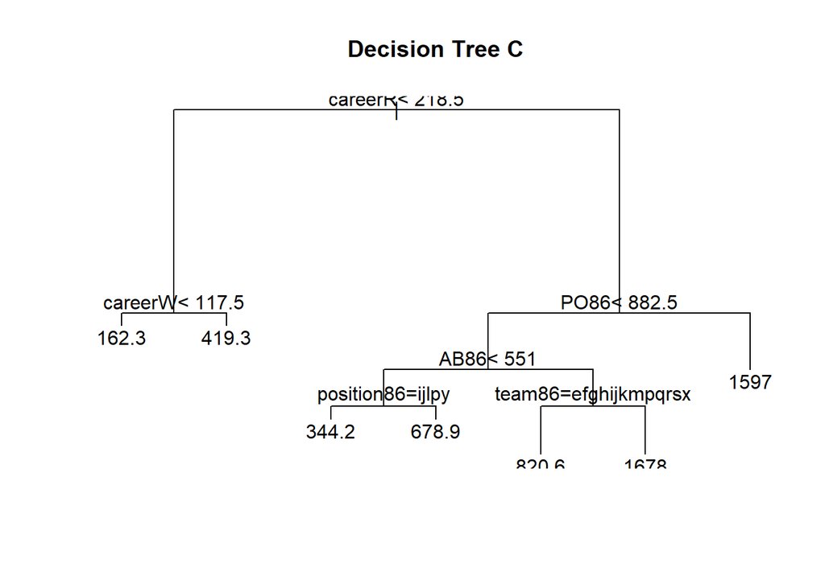

`r rpart.plot(fitI)`

`## Warning: Bad 'data' field in model 'call' (expected a data.frame or a matrix). ## To silence this warning: ## Call rpart.plot with roundint=FALSE, ## or rebuild the rpart model with model=TRUE.`

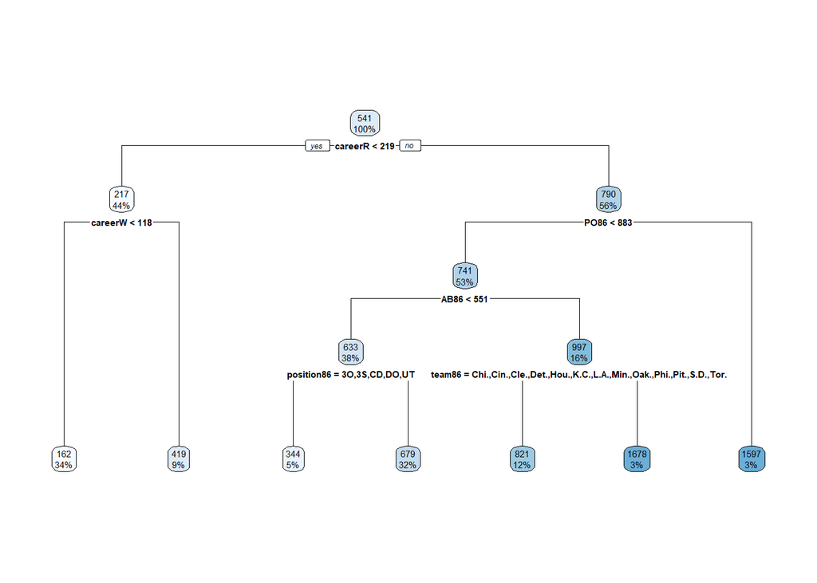

```r #Node number 4: 74 observations # mean=162.2658, MSE=5993.583

#배깅 결정나무는 interaction 적용이 불가능하다 #MSE값이 가장 작은 결정나무 모형A가 가장 적합하다.(?) ```